*Note: These are notes live-tex’d from a graduate course in Floer Homology taught by Akram Alishahi at the University of Georgia in Spring 2021. As such, any errors or inaccuracies are almost certainly my own.*

# Floer Homology

Lectures by Akram Alishahi. University of Georgia, Spring 2021

D. Zack Garza

University of Georgia  
dzackgarza@gmail.com

Last updated: 2021-01-23

# 1 Lecture 1: Overview (Wednesday, January 13)

## 1.1 Course Logistics

> Note (DZG): Everything in this section comes from Akram!

### 1.1.1 Description

“I am teaching a topics course about Heegaard Floer homology next semester. Heegaard Floer homology was defined by Peter Ozsváth and Zoltan Szabó around 2000. It is a package of powerful invariants of smooth 3- and 4-manifolds, knots/links and contact structures. Over the last two decades, it has become a central tool in low-dimensional topology. It has been used extensively to study and resolve important questions concerning unknotting number, slice genus, knot concordance and Dehn surgery. It has been employed in critical ways to study taut foliations, contact structures and smooth 4-manifolds. There are also many rich connections between Heegaard Floer homology and other manifold and knot invariants coming from gauge theory as well as representation theory. We will learn the basic construction of Heegaard Floer homology, starting with the definition of the 3-manifold and knot invariants. In the second half of this course, we will turn to computations and applications of the theory to low-dimensional topology and knot theory. In particular, several numerical invariants have been defined using this homological invariants. At the end of the semester, I would expect each one of you to learn the construction of one of these invariants (of course with my help) and present it to the class.”

### 1.1.2 Expository Papers

- [**G?**] J. Greene, [Heegaard Floer homology](https://www.ams.org/journals/notices/202101/rnoti-p19.pdf)
- [**H?**] J. Hom, [Lecture notes on Heegaard Floer homology](https://arxiv.org/pdf/2008.01836.pdf)
- [**L?**] R. Lipshitz, [Heegaard Floer homologies](https://arxiv.org/abs/1411.4540)
- [**M?**] C. Manolescu, [An introduction to knot Floer homology](https://arxiv.org/abs/1401.7107)
- [**OS-1?**] P. Ozsváth and Z. Szabó, [An introduction to Heegaard Floer homology](https://web.math.princeton.edu/~petero/Introduction.pdf)
- [**OS-2?**] P. Ozsváth and Z. Szabó, [Lectures on Heegaard Floer homology](https://web.math.princeton.edu/~petero/Lectures.pdf)
- [**OS-3?**] P. Ozsváth and Z. Szabó, [Heegaard diagrams and holomorphic disks](https://arxiv.org/pdf/math/0403029.pdf)

### 1.1.3 Research Papers

- [**OSz04a?**] Peter Ozsváth and Zoltán Szabó, Holomorphic disks and topological invariants for closed three-manifolds. Ann. of Math. (2) 159 (2004), no. 3, 1027–1158. [arXiv:math/0101206](https://arxiv.org/abs/math/0101206)
- [**OSz04b?**] Peter Ozsváth and Zoltán Szabó, Holomorphic disks and three-manifold invariants: properties and applications. Ann. of Math. (2) 159 (2004), no. 3, 1159–1245. [arXiv:math/0105202](https://arxiv.org/abs/math/0105202)
- [**OSz04c?**] Peter Ozsváth and Zoltán Szabó, Holomorphic disks and knot invariants. Adv. Math. 186 (2004), no. 1, 58–116. [arXiv:math/0209056](https://arxiv.org/abs/math/0209056)
- [**OSz06?**] Peter Ozsváth and Zoltán Szabó, Holomorphic triangles and invariants for smooth four manifolds. Adv. Math. 202 (2006), no. 2, 326–400. [arXiv:math/0110169](https://arxiv.org/abs/math/0110169)
- [**Per08?**] Timothy Perutz, Hamiltonian handleslides for Heegaard Floer homology. Proceedings of Gökova Geometry-Topology Conference 2007, 15–35, Gökova Geometry/Topology Conference (GGT), Gökova, 2008. [arXiv:0801.0564](https://arxiv.org/abs/0801.0564)

### 1.1.4 Basic Morse Theory, Symplectic Geometry and Floer Homology

- [**Mi-1?**] Milnor, [Morse theory](https://press.princeton.edu/books/paperback/9780691080086/morse-theory-am-51-volume-51)
- [**Mi-2?**] Milnor, [Lectures on the $h{\hbox{-}}$cobordism theorem](https://press.princeton.edu/books/hardcover/9780691651132/lectures-on-the-h-cobordism-theorem)
- [**Ca?**] A. Cannas da Silva. [Lectures on Symplectic Geometry](https://www.springer.com/gp/book/9783540421955)
- [**Mc?**] D. McDuff, [Floer theory and low-dimensional topology](http://www.math.stonybrook.edu/~dusa/floer8.pdf)
- [**AD?**] M. Audin and M. Damian, [Morse theory and Floer homology](https://link.springer.com/book/10.1007/978-1-4471-5496-9)
- [**Hu?**] M. Hutchings, [Lecture notes on Morse homology (with an eye towards Floer theory and pseudoholomorphic curves)](https://math.berkeley.edu/~hutching/teach/276-2010/mfp.ps)

### 1.1.5 Low-dimensional Topology

- [**S?**] N. Saveliev, [Lectures on the topology of 3-manifolds](https://www.degruyter.com/view/title/121170)
- [**R?**] D. Rolfsen, [Knots and links](https://bookstore.ams.org/chel-346-h/)
- [**GS?**] R. Gompf and A. Stipsicz, [4-manifolds and Kirby calculus](https://bookstore.ams.org/gsm-20)
- [**L?**] R. Lickorish, [An introduction to knot theory](https://link.springer.com/book/10.1007/978-1-4612-0691-0)

### 1.1.6 Suggested Topics for Presentations

- [**SW?**] S. Sarkar and J. Wang, [An algorithm for computing some Heegaard Floer homologies, Ann. of Math., 171 (2010), 1213–1236, [arXiv:math/0607777](https://arxiv.org/abs/math/0607777).
- Grid homology from:
  - C. Manolescu and P. Ozsváth and S. Sarkar, [A combinatorial description of knot Floer homology](https://annals.math.princeton.edu/wp-content/uploads/annals-v169-n2-p07.pdf), Ann. of Math., 169 (2009), 633–660, [arXiv:math/0607691](https://arxiv.org/abs/math/0607691).
  - P. Ozsváth and A. Stipsicz and Z. Szabó, [Grid Homology for Knots and Links](https://bookstore.ams.org/surv-208),
    - Also available [here](https://web.math.princeton.edu/~petero/GridHomologyBook.pdf) with comment: please go and buy a hard copy, too!
- J. Hom, [A survey on Heegaard Floer homology and concordance](https://www.worldscientific.com/doi/abs/10.1142/S0218216517400156) J. of Knot Theo. and Its Ram.(2) 26 (2017) [arXiv:1512.00383](https://arxiv.org/abs/1512.00383)
- K. Honda and W. Kazez and G. Matić, [On the contact class in Heegaard Floer homology](https://projecteuclid.org/euclid.jdg/1261495333), J. Differential Geom. (2) 83 (2009), 289-311, [arXiv:math/0609734](https://arxiv.org/abs/math/0609734)
- Sutured Floer homology from:
  - [**L?**] Lipshitz expository paper listed above
  - A. Juhász [Holomorphic discs and sutured manifolds](https://projecteuclid.org/euclid.agt/1513796585) Algebr. Geom. Topol., (3) 6 (2006), 1429-1457, [arXiv:math/0601443](https://arxiv.org/abs/math/0601443)
  - A. Juhász, [Knot Floer homology and Seifert surfaces](https://projecteuclid.org/euclid.agt/1513796824) Algebr. Geom. Topol., (1) 8 (2008), 603-608 [arxiv:math/0702514](https://arxiv.org/abs/math/0702514)

## 1.2 Intro and Motivation

We’ll assume everything is smooth and oriented.

To closed 3-manifolds $M$ we can assign a graded abelian group $\widehat{HF}(M)$, which can be computed combinatorially[^1] . There are several variants:

- $HF^- \in {\operatorname{grMod}}({\mathbb{Z}}_2[u])$,[^2]
- $HF^+ \in {\operatorname{Mod}}({\mathbb{Z}}_2[u, u ^{-1} ] / u {\mathbb{Z}}_2[u])$.
- $HF^\infty \in {\operatorname{grMod}}({\mathbb{Z}}_2[u, u ^{-1} ])$,

$HF^+$ and $HF^\infty$ can be computed using $HF^-$. In general, we’ll write $HF^{\,\cdot\,}$ to denote constructions that work with any of the above variants.

Note that ${\mathbb{Z}}_2$ can be replaced with ${\mathbb{Z}}$, but it’s technical and we won’t discuss it here. For the first half of the course, we’ll just discuss $\widehat{HF}$, and we’ll discuss the latter 3 in the second half.

### 1.2.1 Geometric Information

These invariants can be used to compute the **Thurston seminorm** of a 3-manifold:

A homology class $\alpha\in H_2(M)$ can be represented as $\alpha\in [S]$ for $S$ a closed surface whose fundamental class represents $\alpha$ where $S = \bigcup_{i=1}^n S_i$ can be a union of closed embedded surfaces $S_i$. Then we first compute
$$\begin{align*}
\max\left\{{0, - \chi(S_i) }\right\}
=
\begin{cases}
0 & \text{if } S_i \cong {\mathbb{S}}^2, {\mathbb{T}}^2 \\
\\
- \chi(S_i) = 2g(S_i) - 2 & \text{ else} .
\end{cases}
.\end{align*}
Note that the max checks if \(\chi\) is positive. Then define
\begin{align*}
{\left\lVert { \alpha } \right\rVert} \mathrel{\vcenter{:}}=\min_S \qty{ \sum_{i=1}^n
\max\left\{{0, - \chi(S_i) }\right\} }
,\end{align*}
where we sum over the embedded subsurfaces and check which overall surface gives the smallest norm.$$

Note that this can’t be a norm, since if ${\mathbb{S}}^2, {\mathbb{T}}^2 \in [S] \implies {\left\lVert {\alpha } \right\rVert}= 0$.

$HF$ detects[^3] the Thurston seminorm, and there is a splitting as groups/modules
$$\begin{align*}
HF^{\,\cdot\,}(M) = \bigoplus _{\mathfrak{s} \in {\operatorname{Spin}}^c(M)} HF^{\,\cdot\,}(M, S)
\end{align*}
where \(S \in {\operatorname{Spin}}^c(M)\) is a spin\(^c\) structure: an oriented 2-dimensional vector bundle on \(M\) (up to some equivalence).$$

The Thurston norm ${\left\lVert {a} \right\rVert}$ can be computed from this data by considering a perturbed version of $\widehat{HF}$, denoted $\underline{\widehat{HF}}$, in the following way: taking the first Chern class $c_1(\mathfrak{s}) \in H^2(M)$ (which can be associated to every 2-dimensional vector bundle), we have
$$\begin{align*}
{\left\lVert { \alpha} \right\rVert} = \max_{\underline{\widehat{HF}}(M, \mathfrak{s} ) \neq 0 }
{\left\lvert {{\left\langle { c_1(\mathfrak{s}) },~{ \alpha } \right\rangle} } \right\rvert}
.\end{align*}$$

Floer homology groups split over these spin$^c$ structures and can be used to compute Thurston norms.

Given $F \subseteq M$ with genus $g\geq 2$, $HF$ detects if $M$ *fibers* over $S^1$ with $F$ as a fiber, i.e. there exists a fiber bundle

[figure not shown]

This uses the existence of the splitting over spin$^c$ structures and uses $HF^+$ in the following way: such a bundles exists if and only if
$$\begin{align*}
\bigoplus _{{\left\langle { c_1(\mathfrak{s}) },~{ [F] } \right\rangle} =2g-2} HF^+(M, \mathfrak{s}) = {\mathbb{Z}}
.\end{align*}$$

Equivalently,

- A smooth oriented nowhere integrable 2-plane field $\xi$, or
- A 2-plane field $\xi \mathrel{\vcenter{:}}=\ker( \alpha)$ where $\alpha$ is a 1-form such that $\alpha\wedge d \alpha > 0$.[^4]

The standard contact structure on ${\mathbb{R}}^3$ is given by
$$\begin{align*}
\alpha\mathrel{\vcenter{:}}= dz - ydz
,\end{align*}
which yields the following 2-plane field \(\xi \mathrel{\vcenter{:}}=\ker \alpha\):$$

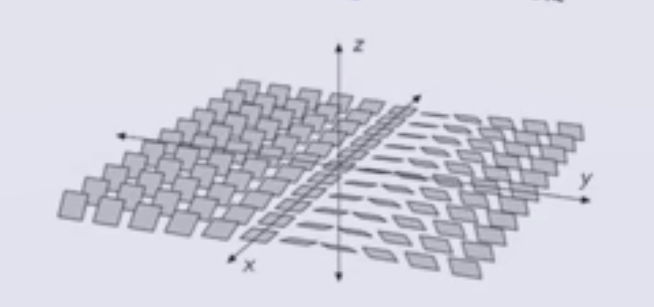

2-Plane Field in ${\mathbb{R}}^3$

You can see that $z=0 \implies y=0$, so the $xy{\hbox{-}}$plane is in the kernel, yielding the flat planes down the middle:

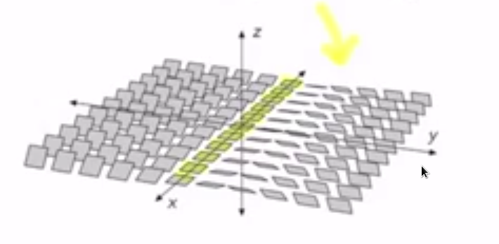

Flat Planes

To each such $\xi$ one can associate a **contact class** $c(\xi) \in \widehat{HF}(-M)$, where $-M$ is $M$ with the reversed orientation.

This gives obstructions for two of the following important properties of contact structures:

- Being **overtwisted**, or
- Being **Stein fillable**.
- If $\xi$ is overtwisted, then $c(\xi) = 0$.
- If $\xi$ is Stein fillable, then $c(\xi) \neq 0$.

We’ll also discuss similar invariants for knots that were created after these invariants for manifolds.

Recall that a **knot** is an embedding $S^1 \hookrightarrow M$.

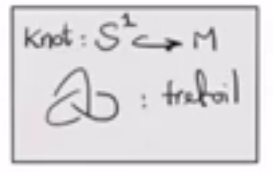

Example: the trefoil knot

Given a knot $K \subseteq M$ a 3-manifold (e.g. $M = S^3$), there is extra algebraic structure on $\widehat{CF}(M)$: a filtration. These allow defining a new bigraded abelian group $\widehat{HFK}(M, K)$ (which is also a ${\mathbb{Z}}_2{\hbox{-}}$vector space) that takes includes the information of $K$. This yields a decomposition
$$\begin{align*}
\widehat{HFK}(M, K) = \bigoplus _{m, a} \widehat{HFK}_m(M, K, a)
.\end{align*}$$

This similarly works for other variants: there is a filtration on $CF^-(M)$ which yields $HFK^-(M, K)$, a bigraded ${\mathbb{Z}}_2[u]{\hbox{-}}$module.

Some properties of Knot Floer Homology:

$\widehat{HFK}(K)$ categorifies the Alexander polynomial $\Delta_K(t)$ of $K$, i.e. taking the graded Euler characteristic yields
$$\begin{align*}
\Delta_K (t) =\sum_{m, a} (-1)^m\qty{ \dim \widehat{HFK}_m(K, a) } t^a
.\end{align*}$$

$\widehat{HFK}(K)$ detects the **Seifert genus** of a knot $g(K)$, defined as the smallest $g$ such that there exists an embedded surface[^5] $F$ of genus $g$ in $S^3$ that bounds $K$, so ${{\partial}}F = K$.

The unknot bounds a disc, so its genus is zero:

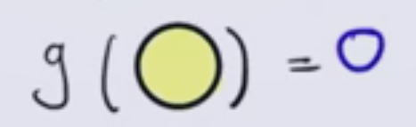

The genus of the unknot

Using the “outside” disc on the trefoil, find 3 bands that show its genus is 1.

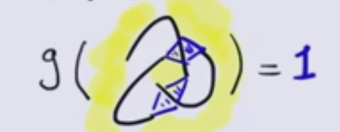

The genus of the trefoil

The genus can be computed by setting $\widehat{HFK}(K, a) \mathrel{\vcenter{:}}=\bigoplus _m \widehat{HFK}_m(K, a)$, which yields
$$\begin{align*}
g(k) = \max \left\{{ a {~\mathrel{\Big|}~}\widehat{HFK}(K, a) \neq 0 }\right\}
.\end{align*}
Note that the \(a\) grading here is referred to as the Alexander grading.$$

$\widehat{HFK}$ detects whether or not a knot is **fibered**, where $K$ is fibered if and only if it admits an $S^1$ family $F_t$ of Seifert surfaces such that $t\neq s\in S^1 \implies F_t \cap F_s = K$. I.e., there is a fibration on the knot complement where each fiber is a Seifert surface:

[figure not shown]

The unknot is fibered by ${\mathbb{D}}^2$s:

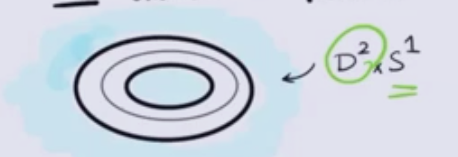

The unknot fibered by discs.

This is “detected” in the following sense: $K$ is fibered if and only if
$$\begin{align*}
\widehat{HFK}(k, g(K)) = {\mathbb{Z}}_2
.\end{align*}$$

Let $K \subseteq S^3$. We know $S^3 = {{\partial}}B^4$, so we consider all of the smoothly properly embedded surfaces $F$ in $B^4$ such that ${{\partial}}F = K$ and take the smallest genus:

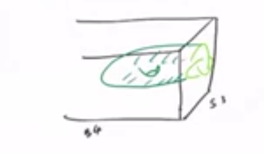

Knot in $S^3$ bounding a surface in $B^4$

We thus define the **slice genus** or **4-ball genus** as
$$\begin{align*}
g_S(K) \mathrel{\vcenter{:}}= g_4(K) \mathrel{\vcenter{:}}=\min
\left\{{
g(F) {~\mathrel{\Big|}~}F\hookrightarrow B^4 \text{ smootherly, properly with } {{\partial}}F = K
}\right\}
.\end{align*}$$

Show that $g_4(K) \leq g(K)$.

Define $u(K)$ the **unknotting number** of $K$ as the minimum number of times that $K$ must cross itself to become unknotted.

Consider changing the bottom crossing of a trefoil:

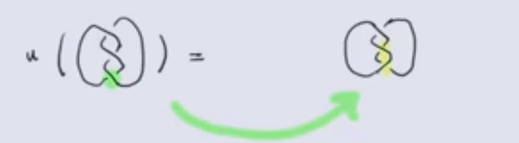

Changing one crossing in the trefoil

This in fact produces the unknot:

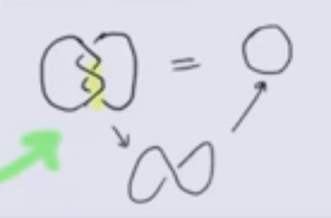

Unkink to yield the unknot

Thus $u(K) = 1$, assuming that we know $K \neq 0$ is not the unknot.

Show that $g_f(K) \leq u(K)$.

> Hint: each crossing change $K\to K'$ yields some surface that is a cobordism from $K$ to $K'$ in $B^4$, and you can use each step to build your surface.

Define an invariant $\tau(K) \in {\mathbb{Z}}$ from $\widehat{HFK}$ such that ${\left\lvert {\tau(K)} \right\rvert} \leq g_4(K) \leq u(K)$.

The torus knot $T_{2, 3}$ wraps 3 times around the torus in one direction and twice in the other:

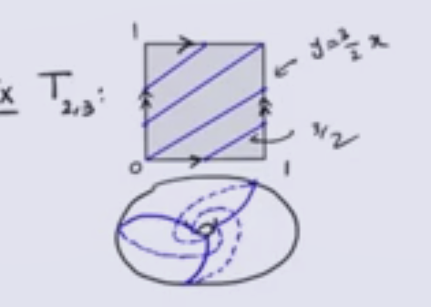

The torus knot $T_{2, 3}$

- First proved by Kronheimer-Mrowka
- Another proof by Osvath-Szabó using Heegard Floer homology.

Show that $u(T_{p. q}) \leq {(p-1)(q-1) \over 2}$, i.e. torus knots can be unknotted with this many crossing changes.

$$\begin{align*}
\tau(T_{p, q}) =
{(p-1)(q-1) \over 2}
,\end{align*}$$

which implies
$$\begin{align*}
{(p-1)(q-1) \over 2}
\leq g_4(T_{p, q})
\leq u(T_{p, q})
\leq {(p-1)(q-1) \over 2}
,\end{align*}
making all of these equal.$$

There are better lower bounds for $u(K)$ defined using $\widehat{HFK}$ which are *not* lower bounds for the slice genus. There are also other lower bounds for the slice genus with different names (see Jen Hom’s survey), some of which are stronger than $\tau$.

Another application of having these lower bounds is that we can construct exotic (or *fake*) ${\mathbb{R}}^4$s, i.e. 4-manifolds $X$ homeomorphic to ${\mathbb{R}}^4$ but not diffeomorphic to ${\mathbb{R}}^4$.

All of these invariants work nicely in a $(3+1){\hbox{-}}$TQFT: we have invariants of 3-manifolds $M_i$ and knots in them, so we can talk about **cobordisms** between them: $W^4$ a compact oriented 4-manifold with ${{\partial}}W^4 = -M_1 {\coprod}M_2$.

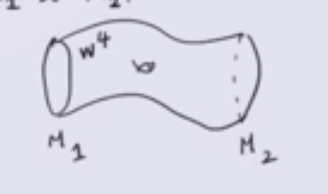

A cobordism

Osvath-Szabó define a map
$$\begin{align*}
F_{W, t}^{\,\cdot\,}: HF^{\,\cdot\,}(M_1, { \left.{{t}} \right|_{{M_1}} } ) \to HF^{\,\cdot\,}(M_2, { \left.{{t}} \right|_{{M_2}} })
\end{align*}
using \(t\) coming from the splitting of spin\(^c\) structure which yields an invariant of closed 4-manifolds referred to as mixed invariants.$$

Similarly, if we have knots in 3-manifolds we can define a cobordism $(M_1, K_1) \to (M_2, K_2)$ as $(W^4, F)$ where $W^4$ is a cobordism $M_1\to M_2$ and $F\hookrightarrow W$ is a smoothly embedded surface that is a cobordism from $K_1\to K_2$ with $F \cap M_i = K_i$ and ${{\partial}}F = -K_1 {\coprod}K_2$.

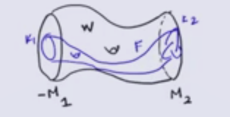

A cobordism including knots

This similarly yields a map

$$\begin{align*}
F_{W, F t}^{\,\cdot\,}: HF^{\,\cdot\,}(M_1, K_1, { \left.{{t}} \right|_{{M_1}} } ) \to HF^{\,\cdot\,}(M_2, K_2, { \left.{{t}} \right|_{{M_2}} })
\end{align*}$$

This smoothly embedded surface in the middle can be used to study other smoothly embedded surfaces in 4-manifolds, which has been done recently.

# 2 Lecture 2 (Tuesday, January 19)

For Morse Theory, there are some good exercises in Audin’s book – essentially anything other than the existence questions. The first 8 look good on p. 18.

Today:

1. Overview of the construction of HF, and
2. A discussion of Morse Theory.

## 2.1 Constructing Heegard Floer

First goal: discuss how the name “Heegard” fits in.

A **genus $g$ handlebody** $H_g$ is a compact oriented 3-manifold with boundary obtained from $B^3$ by attaching $g$ solid handles (a neighborhood of an arc).

For $g=2$ attached to a sphere, we glue $D^2 \times I$ by its boundary to $S^2$.

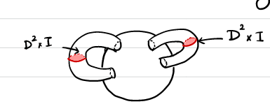

In general, ${{\partial}}H_g = \Sigma_g$ is a genus $g$ surface, and $H_g \setminus{\coprod}_{i=1}^g D_i = B^3$. We can keep track of the data by specifying $(\Sigma, \alpha_1, \alpha_2, \cdots, \alpha_g)$ where ${{\partial}}D_i = \alpha_i$.

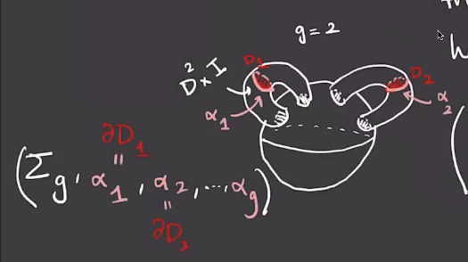

Attaching a handlebody

A **Heegard diagram** is $M = H_1 \cup_{{\partial}}H_2$ where $H_i$ are genus $g$ handlebodies and there is a diffeomorphism ${{\partial}}H_1 \to {{\partial}}H_2$.

Every closed 3-manifold has a Heegard decomposition, although it is not unique.

A **Heegard diagram** is the data $(\Sigma_g, \alpha = \left\{{ \alpha_1, \cdots, \alpha_g}\right\}, \beta = \left\{{ \beta_1, \cdots, \beta_g}\right\})$ where the $\alpha$ correspond to $H_1$ and $\beta$ to $H_2$ and $\Sigma_g = {{\partial}}H_1 = {{\partial}}H_2$.

## 2.2 Lagrangian Floer Homology

This is essentially an infinite-dimensional version of Morse homology.

A **symplectic manifold** is a pair $(M^{2n}, \omega)$ such that

- $\omega$ is *closed*, i.e. $d \omega = 0$, and
- $\omega$ is *nondegenerate*, i.e. $\wedge^n \omega \neq 0$.

A **Lagrangian submanifold** is an $L^n \subseteq M$ such that ${ \left.{{\omega}} \right|_{{L}} } = 0$.

If $L_1 \cap L_2$ is finitely many points, case we can define a chain complex
$$\begin{align*}
CF(M^{2n}, L_1, L_2) \mathrel{\vcenter{:}}={\mathbb{Z}}_2[L_1 \cap L_2]
,\end{align*}
the \({\mathbb{Z}}_2{\hbox{-}}\)vector space generated by the intersection points of the Lagrangian submanifolds. We’ll define a differential by essentially counting discs between intersection points:$$

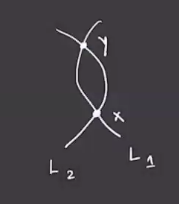

Two intersection points

We’ll want to write ${{\partial}}x = c_y y + \cdots$ where $c_y$ is some coefficient. How do we compute it? In this case, we have half of the boundary on $L_1$ and half is on $L_2$

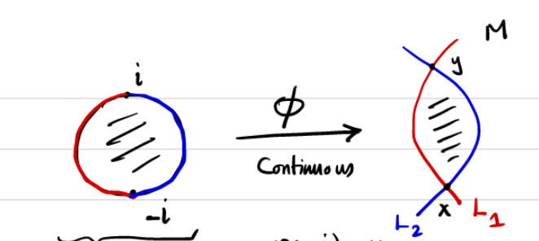

Given a 3-manifold $M^3$, we’ll associate a Heegard diagram $\Sigma, \alpha, \beta$. Note the $g{\hbox{-}}$element symmetric group acts on $\prod_{i=1}^g \Sigma$ by permuting the $g$ coordinates, so we can define $\operatorname{Sym}^g(\Sigma) \mathrel{\vcenter{:}}=\prod_{i=1}^g \Sigma / S_g$.

The space $\operatorname{Sym}^g(\Sigma)$ is a smooth complex manifold of ${\mathbb{R}}{\hbox{-}}$dimension $2g$.

Write ${\mathbb{T}}_{\alpha} \mathrel{\vcenter{:}}=\prod_{i=1}^g \alpha_i \subseteq \prod_{i=1}^g \Sigma$ for a $g{\hbox{-}}$dimensional torus; this admits a quotient map to $\operatorname{Sym}^g(\Sigma)$. We can repeat this to obtain ${\mathbb{T}}_{\beta}$. Then $HF^{\,\cdot\,}(M)$ will be a variation of Lagrangian Floer Homology for $(\operatorname{Sym}^g(\Sigma), {\mathbb{T}}_{\alpha}, {\mathbb{T}}_{\beta} )$.

Consider constructing a genus $g=1$ Heegard diagram. Recall that $S^3$ can be constructed by gluing two solid torii.

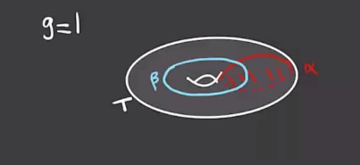

Here $(T, \alpha, \beta)$ will be a Heegard diagram for $S^3$.

Show that the following diagram with $\beta$ defined as some perturbation of $\alpha$ is a Heegard diagram for $S^1 \times S^2$.

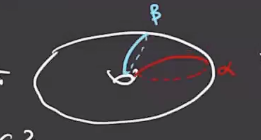

Consider $M$ a 3-manifold containing a knot $K$, we can construct a new 3-manifold by first removing a neighborhood of $K$ to yield $M\setminus N(K)$:

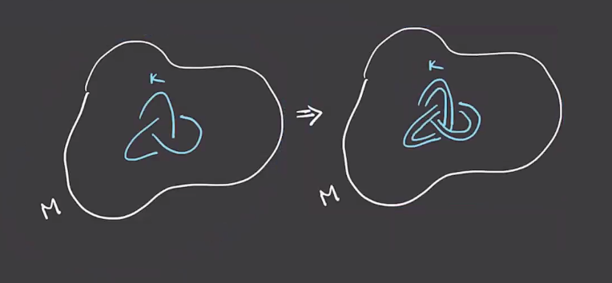

Taking a new solid torus $S \mathrel{\vcenter{:}}={\mathbb{D}}^2 \times S^1$ and a diffeomorphism $i: {{\partial}}S \to {{\partial}}(M \setminus N(K))$, this yields a new manifold $M _{\varphi} (K)$, a **surgery** along $K$.

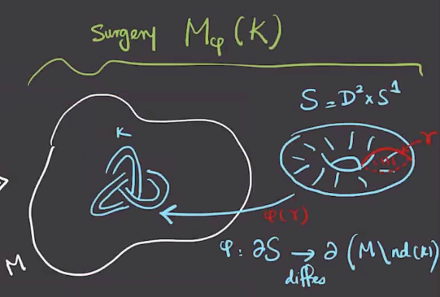

Next time: we’ll talk about “integer surgeries.”